# Laboratorio di Programmazione Gr. 3 (N-Z)

# Corso di Laurea in Informatica

## Università degli Studi di Napoli Federico II

## A.A. 2021/22

### Layout della memoria di un programma C

Un programma C in esecuzione utilizza 4 regioni di memoria logicamente distinte:

1. regione dedicata a contenere il codice in esecuzione (**text/code area**)
2. regione dedicata a variabili `external`, `global` e `static`. Si divide a sua volta in:
   - **initialized data segment**: variabili `extern`, `global` e `static` i cui valori **sono inizializzati** in fase di dichiarazione
   - **uninitialized data segment** (*bss, block started by symbol*): variabili `extern`, `global` e `static` non inizializzate in fase di dichiarazione. Il kernel inizializza queste variabili a 0 (o `NULL` nel caso di puntatori) prima che il programma entri in esecuzione
3. l'**execution stack**, o *call stack*, o spesso chiamato comunemente *stack* (anche se fonte di ambiguità), contenete gli indirizzi di ritorno delle funzioni invocanti, argomenti e **variabili locali**. Il termine *stack* si riferisce alla *politica di accesso* (LIFO, Last In First Out).
4. l' **heap**, regione di spazio libero utilizzata per l'allocazione dinamica (NB: nessuna relazione con l'omonima struttura dati)

il comando linux`size` fornisce informazioni sull'occupazione di memoria di un programma:

`esempio.c`:

```
#include<stdio.h>

int main() {
    return 0;
}
```

`gcc esempio.c -o esempio`

`size esempio`

output:

```
text    data     bss     dec     hex  filename
1418     544       8    1970     7b2   esempio
```

La dimensione massima dell' *execution stack* può essere recuperata con il comando `ulimit -s` (l'output è espresso in KB).

`ulimit -s`

output:

`8192`

In questo caso, lo spazio a disposizione nell' execution stack è 8192 KB.

### Tipi di allocazione in C

Il C supporta due tipi di allocazione di memoria:

- *static allocation*: destinata alle variabili `global` o `static`. Per Ogni variabile viene definito un blocco di spazio di dimensione fissata. Lo spazio viene allocato *all'avvio del programma*.
- *automatic allocation*: destinata alle variabili `automatic`, come gli argomenti di funzione o le varibili locali. Tali variabili vengono allocate quando il programma entra materialmente nel blocco in cui tali variabili sono definite, e deallocate quando termina tale blocco.

Una terza tipologia di allocazione, la *dinamic allocation*, non è supportata "in maniera diretta" dal C, ma è disponibile attraverso funzioni di libreria apposite. L'allocazione dinamica è necessaria quando non si conosce *a priori* quanta memoria è necessaria.

### Il concetto di **object**

> **object**: region of data storage in the execution environment, the contents of which can represent values

> (From: *C committee draft* www.open-std.org/jtc1/sc22/wg14/www/docs/n1256.pdf)

**NESSUNA** relazione con la *Programmazione ad Oggetti*

Quindi in *C*, una regione di memoria contenente dati è chiamata genericamente **object** (variabili, array, etc.)

`int answer = 42;`

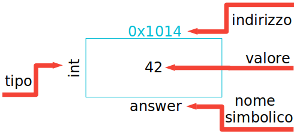

## Dichiarazione Vs Definizione (object)

> **Dichiarazione**: dichiara il nome ed il tipo di un object (in sostanza dice che l'object esiste da qualche parte)

> **Definizione**: alloca lo spazio necessario per l'object (in sostanza viene materialmente creato in memoria)

In molti casi, le due fasi corrispondono. Esempio: `int a;` dichiara che esiste un object di nome `a` di tipo `int`, e contemporaneamente ne alloca lo spazio in memoria.

In generale, in uno stesso programma,un object può avere *più* dichiarazioni *ma una sola* definizione.

Esempio di un object *dichiarato* ma non *definito*:

`extern int g;`

`extern` *dichiara* l'esistenza dell'object `g`, *definito* (adesso o in futuro) da qualche altra parte. Il compilatore quindi, nel caso in cui sia richiesto l'utilizzo di `g` prima dell'effettiva *definizione*, non se ne preoccupa e continua il processo di compilazione (in quanto semplice traduzione).

Esempio:

```python
#include <stdio.h>
int main(void)
{
    extern int first, last; /* use global vars */
    printf("i valori di first e last sono: %d %d\n", first, last);
    return 0;
}
/* global definition of first and last */
int first = 10, last = 20;
```

```
i valori di first e last sono: 10 20
```

dato che si richiede l'utilizzo di `first, last` *prima* della loro effettiva *definizione*, vanno almeno *dichiarate* in precedenza.

## Inizializzazione Vs Assegnazione

> **Assegnazione**: dare valore ad un object in qualsiasi punto del programma

> **Inizializzazione**: dare valore ad un object *in fase di definizione*

```
{
    int a; // dichiarazione & definizione
    a = 3; // assegnazione
}
```

```
{
    int a = 3; // dichiarazione & definizione & inizializzazione
}
```

In C, alcune cose lecite in fase di inizializzazione non lo sono in fase di assegnazione.

Ad ogni modo, un object è detto **inizializzato** se gli è stato dato un valore dal programma, indipendentemente dal modo in cui ciò sia avvenuto.

Esempio:

```
int V[] = {1,2,3}; // si può fare
int Q[];
Q[] = {4,5,6}; // non si può fare
```

```
const int i = 5; // si può fare
const int i;
i = 5; // non si può fare
```

# Strutture dati native del C

Una struttura dati è un insieme di dati di tipi base aggregati assieme secondo uno schema.

Il C mette a disposizione in maniera nativa le seguenti strutture dati:

- **array**:
  - monodimensionali
  - multidimensionali
- **struct**:
  - semplici
  - ricorsive

# Array

> Un array è una *sequenza* di elementi di tipo *omogeneo*

##### Array **Monodimensionali**:

```
int V[12];
```

##### Array **Multidimensionali**:

```
int K[3][4];       // array di 12 elementi distribuiti lungo 2 dimensioni
int W[2][3][2];    // array di 12 elementi distribuiti lungo 3 dimensioni
int Q[1][2][2][3]; // array di 12 elementi distribuiti lungo 4 dimensioni
```

Gli *indici* di un array vengono utilizzate per identificare un elemento in fase di lettura/scrittura, esattamente come in un sistema di coordinate.

```
K[2][0]       = 5;  // assegno il valore 5 alla posizione di indici (2,0)
    W[2][0][0]    = 5;  // assegno il valore 5 alla posizione di indici (2,0,0)
    Q[0][2][0][0] = 5;  // assegno il valore 5 alla posizione di indici (0,2,0,0)
```

## Array monodimensionali

```
int V[12];
V[4] = 2;
```

Da notare che l'operatore `[]` assume due significati differenti in base a dove è usato:

- in fase di **dichiarazione/definizione**: specifica **quanti** elementi compongono l'array
- in fase di **accesso**: specifica **dove** leggere/scrivere il dato. In tale fase è detto anche *subscript operator*.

il valore tra `[]` deve essere di tipo intero, e può essere sia un valore costante che una variabile. Esempio:

```
int a = 4;
v[a]  = 42; // inserisce nella posizione di indice 4 il valore 42
```

In fase di accesso i valori plausibili vanno da `0` a `n-1` dove `n` è il numero di elementi che compongono l'array esplicitato in fase di dichiarazione.

## Matrici

Un array a due dimensioni viene chiamato anche *matrice*. In quanto tale, può venire facilmente rappresentata in forma tabellare in termini di righe (associate alla prima dimensione) e colonne (associate alla seconda dimensione)

`cint K[3][4] = {{3,2,1,1},{7,9,7,7},{5,4,2,4}};`

corrisponde logicamente a

$$ K= \begin{pmatrix} 3 & 2 & 1 & 1 \\ 7 & 9 & 7 & 7 \\ 5 & 4 & 2 & 4\\ \end{pmatrix} $$

L'istruzione

```
K[1][2] = 0;
```

## Allocazione di un array

Essendo le locazioni di memoria disposte fisicamente in maniera "sequenziale", l'allocazione di un array multidimensionale in memoria non è, ovviamente, tabellare/multidimensionale, ma sempre monodimensionale, ossia:

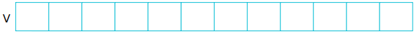

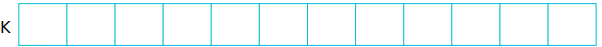

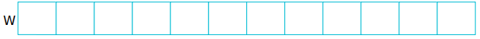

Come si vede, a parità, di numero di elementi, lo spazio è allocato esattamente nello stesso modo, indipendentemente dal numero di assi/dimensioni utilizzato. Ciò che cambia è l'associazione tra gli indici e gli elementi effettivi.

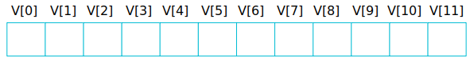

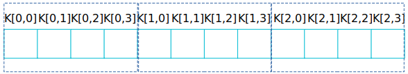

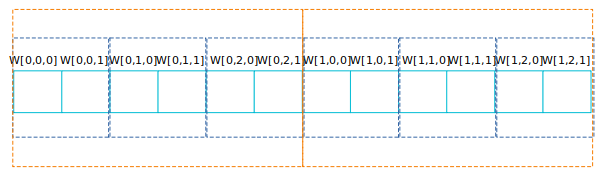

La strategia di assocazione indici-elementi di un array multidimensionali utilizzati in C è detta *row-major order*.

Esempio di *column-major order*:

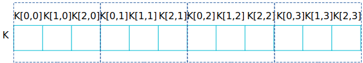

#### Array sovradimensionati

La dimensione dei vettori automatici viene decisa nel codice sorgente, e quindi fissata a *compile time*. Spesso però si vorrebbe che la dimensione effettiva di tali vettori possa essere impostata durante la materiale esecuzione del programma, ossia *run-time*. Esempi:

- dato un vettore di 10 elementi, costruire un secondo vettore contenente soltanto gli elementi pari di quest'ultimo (non si può determinare la lunghezza del secondo vettore se non dopo una scansione del primo vettore a run time del primo)
- acquisire dall'utente un vettore di $n$ interi con $n$ *deciso dall'utente* (Impossibile sapere la lunghezza del vettore prima del run time in cui l'utente comunica quanti elementi inserire)

In questi casi, le possibilità sono almeno due:

- utilizzo di *allocazione* dinamica della memoria (vedremo poi)
- utilizzare una *stima* della lunghezza

Ad esempio:

- se si vuole produrre un "sottovettore", la lunghezza sarà *al più* pari alla lunghezza del vettore di partenza
- se la dimensione è decisa dall'utente, si può fare una stima di quanti elementi un utente potrebbe inserire (e.g., non più di 100), avvisandolo opportunamente di tale limite.

Entrambe queste soluzioni fanno uso di vettori sovradimensionati. Sarà necessaria quindi una ulteriore variabile che contenga quanti siano gli elementi realmente utilizzati.

Esempio:

```
int main()
{
    int V[12]; // dichiaro un vettore di 12 elementi
    int n;      // variabile di supporto contenente il numero di elementi effettivi
    printf("quanti elementi vuoi inserire nel vettore? (NB: MAX 12)");
    scanf("%d",&n);

    for(int i=0; i < n; i++) // l'accesso al vettore avviene soltanto sui primi n elementi
    {
        scanf("%d",&V[i]);

    }

    return 0;
}
```

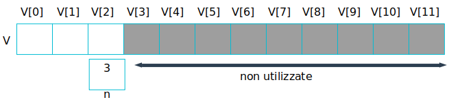

In alcuni testi, la variabile contenente il numero di elementi effettivi del vettore è detta *riempimento*. **S**consiglio di usare questo termine.

Lo stesso discorso si può generalizzare al caso degli array multidimensionali. Ad esempio, nel caso delle matrici, si può chiedere all'utente di fornire il numero di righe ed il numero di colonne materialmente utilizzate, a fronte di una matrice allocata sovradimensionata.

Potreste aver sentito parlare degli array di lunghezza variabile (*Variable Length Array*, VLA). Non saranno trattati in questo corso.

# (Possibili) soluzioni ad (alcuni) esercizi

```python
/*
Dato un vettore ed un valore k,
ricerca di k all'interno di un vettore
(versione NON ottimizzata, usare un for (o while) che scorre il vettore fino alla fine)
*/
#include <stdio.h>

int main()
{
    int vett[] = {1,4,8,2};
    int n      = 4;
    int k      = 8;
    int trovato= 0;
    for(int i = 0; i < n; i++)
    {
        if (k == vett[i])
        {
            trovato = 1;
        }
    }

    if (trovato == 1)
        printf("il valore %d è contenuto nel vettore\n", k);
    else
        printf("il valore %d non è contenuto nel vettore\n", k);
    return 0;
}
```

```
il valore 8 è contenuto nel vettore
```

```python
/*
Dato un vettore ed un valore k, ricerca di k all'interno di un vettore
(il ciclo si deve fermare quando l'elemento è stato trovato,
USARE UN WHILE NON UN FOR)
*/
#include <stdio.h>

void stampa_vett(int vett[], int n)
{
    printf("(");
    for(int i=0; i<n; i++)
        printf("%d, ", vett[i]);
    printf("\b\b)\n");
}


int main()
{
    int vett[]  = {1,4,8,2};
    int n       = 4;
    int k       = 5;
    int trovato = 0;
    int i       = 0;
    while(i < n && trovato == 0)
    {
        if (k == vett[i])
        {
            trovato = 1;
        }
        i++;
    }
    printf("vettore: ");
    stampa_vett(vett, n);
    printf("cerco il valore %d...\n", k);
    if (trovato == 1)
        printf("il valore %d è contenuto nel vettore\n", k);
    else
        printf("il valore %d non è contenuto nel vettore\n", k);
    return 0;
}
```

```
vettore: (1, 4, 8, 2)
cerco il valore 5...
il valore 5 non è contenuto nel vettore
```

```python
// versione alternativa
#include <stdio.h>

void stampa_vett(int vett[], int n)
{
    printf("(");
    for(int i=0; i<n; i++)
        printf("%d, ", vett[i]);
    printf("\b\b)\n");
}

int cerca(int v[], int dim, int key)
{
    int i  = 0;
    while(i < dim)
    {
        if (key == v[i])
        {
            break;
        }
        i++;
    }

    if (i < dim)
        return 1;
    else
        return 0;
}
int main()
{
    int vett[]  = {1,4,8,2};
    int n       = 4;
    int k       = 8;

    printf("vettore: ");
    stampa_vett(vett, n);

    printf("cerco il valore %d...\n", k);

    int trovato = cerca(vett, n, k);
    if (trovato == 1)
        printf("il valore %d è contenuto nel vettore\n", k);
    else
        printf("il valore %d non è contenuto nel vettore\n", k);
    return 0;
    return 0;
}
```

```
vettore: (1, 4, 8, 2)
cerco il valore 8...
il valore 8 è contenuto nel vettore
```

```python
/*
Dato un array ed valore k, contare quante volte appare k nell' array
*/
#include <stdio.h>

void stampa_vett(int vett[], int n)
{
    printf("(");
    for(int i=0; i<n; i++)
        printf("%d, ", vett[i]);
    printf("\b\b)\n");
}

int conta(int v[], int dim, int key)
{
    int c  = 0;
    int i  = 0;
    while(i < dim)
    {
        if (key == v[i])
        {
            c++;
        }
        i++;
    }

    return c;
}
int main()
{
    int vett[]  = {1,4,8,2,4};
    int n       = 5;
    int k       = 4;

    printf("vettore: ");
    stampa_vett(vett, n);

    printf("conto quante volte appare il valore %d nel vettore...\n", k);
    int freq = conta(vett, n, k);

    if (freq > 0)
        printf("il valore %d è contenuto nel vettore %d volte\n", k, freq);
    else
        printf("il valore %d non è contenuto nel vettore\n", k);

    return 0;
}
```

```
vettore: (1, 4, 8, 2, 4)
conto quante volte appare il valore 4 nel vettore...
il valore 4 è contenuto nel vettore 2 volte
```

```python
/*
determinare il minimo (massimo) presente in un vettore e stamparne a video
sia valore che la posizione in cui si trova.
Esempio: dato `A = 1,3,5,-2,4,0,6` allora stampa `il minimo è -2 e la posizione in cui si trova è 3`
*/

#include <stdio.h>


void stampa_vett(float vett[], int n)
{
    printf("(");
    for(int i=0; i<n; i++)
        printf("%.2f, ", vett[i]);
    printf("\b\b)\n");
}

int idx_min_array(float v[], int n)
{
    /*
    dato un array di lunghezza n, viene restituito l'indice del valore più piccolo
    */
    int   idx = 0;
    for (int i=1; i<n; i++)
        if (v[i] < v[idx])
            idx = i;
    return idx;
}

int idx_max_array(float v[], int n)
{

    /*
    dato un array di lunghezza n, viene restituito l'indice del valore più grande
    */
    int   idx = 0;
    for (int i=1; i<n; i++)
        if (v[i] > v[idx])
            idx = i;
    return idx;

}

int main()
{
    float v[] = {3,1,2,4,6,8,9,-5};
    int n     = 8;
    int idx_min = idx_min_array(v,n);
    int idx_max = idx_max_array(v,n);
    printf("vettore: ");
    stampa_vett(v, n);
    printf("min: %.2f    max: %.2f\n", v[idx_min], v[idx_max]);
    printf("idx: [%4d]       [%4d]\n", idx_min, idx_max);
}
```

```
vettore: (3.00, 1.00, 2.00, 4.00, 6.00, 8.00, 9.00, -5.00)
min: -5.00    max: 9.00
idx: [   7]       [   6]
```

```python
/* Dato un vettore ed un indice di posizione idx,
eliminazione  dell'elemento in posizione idx tramite shift a sinistra
*/
/* Dato un vettore ed un indice di posizione idx,
eliminazione  dell'elemento in posizione idx tramite shift a destra
*/
#include <stdio.h>

void stampa_vett(int vett[], int n)
{
    printf("(");
    for(int i=0; i<n; i++)
        printf("%d,", vett[i]);
    printf("\b)\n");
}

void shift_sx(int vett[],int* n, int pos)
{
    for(int i = pos; i < (*n)-1; i++)
        vett[i] = vett[i+1];
    (*n)--;
}

void shift_dx(int vett[], int* n, int pos, int ins)
{
    /*
    NB: ovviamente il vettore vett mi aspetto che sia sovradimensionato di
    almeno una posizione
    */
    for(int i = *n; i >pos; i--) /* parto dalla prima posizione libera
                                trascinandomi gli elementi all'indietro*/
        vett[i] = vett[i-1];
    vett[pos] = ins;
    (*n)++;
}


int main()
{
    int v[] = {1, 3, 5, 2, 4, 8};
    int n   = 6;
    int k   = 3;
    printf("prima di shift a sx dalla posizione %d:\n",k );
    stampa_vett(v, n);
    shift_sx(v,  &n, k);
    printf("dopo lo shift a sx dalla posizione %d:\n",k );
    stampa_vett(v, n);


    int ins=50;
    shift_dx(v, &n, k, ins);
    printf("dopo lo shift a dx dalla posizione %d e inserendo il valore %d:\n",k,ins );
    stampa_vett(v, n);


    return 0;
}
```

```
prima di shift a sx dalla posizione 3:
(1,3,5,2,4,8)
dopo lo shift a sx dalla posizione 3:
(1,3,5,4,8)
dopo lo shift a dx dalla posizione 3 e inserendo il valore 50:
(1,3,5,50,4,8)
```

```python
// Dato un vettore, eliminarne i duplicati tramite shift
#include <stdio.h>
void stampa_vett(int vett[], int n)
{
    printf("(");
    for(int i=0; i<n; i++)
        printf("%d,", vett[i]);
    printf("\b)\n");
}

void shift_sx(int vett[],int* n,  int pos)
{
    for(int i = pos; i < *n; i++)
        vett[i] = vett[i+1];
    (*n)--;
}


int is_presente(int vett[], int n, int val)
{
    int trovato = 0;
    int i       = 0;
    while(trovato == 0 && i < n)
    {
        if( vett[i] == val)
            trovato = 1;
        i++;
    }

    return trovato;

}

void elimina_doppioni(int vett[], int* n)
{
    int i = 0;
    while(i < *n)
    {
        int pres = is_presente( vett, i, vett[i] ); // controllo se vett[i] è presente
                                                    // nelle i posizioni precedenti
        if (pres == 1)                              // se è presente
            shift_sx(vett, n, i);                   // lo elimino
        else
            i++; /*
                    incremento i solo nel caso in cui non sia stato
                    eliminato il valore i-esimo.
                    Questo perchè, nel caso in cui il valore in posizione di indice i
                    sia stato eliminato,
                    grazie allo spostamento causato dallo shift
                    la posizione di indice i contiene adesso
                    il prossimo valore da esaminare
                */
    }

}


#define MAX_LEN 100
int main()
{
    int A[] = {1,2,3,2,3,8,8,5,5,2,8,6};
    int n_A = 12;
    printf("vettore iniziale: ");
    stampa_vett(A, n_A);

    elimina_doppioni(A, &n_A);

    printf("vettore ripulito: ");
    stampa_vett(A, n_A);
}
```

```
vettore iniziale: (1,2,3,2,3,8,8,5,5,2,8,6)
vettore ripulito: (1,2,3,8,5,6)
```

```python
/*
Dato un vettore, stamparne  un diagramma a barre fatto di `*` .
    esempio: vettore: [ 3 6 4] la stampa sarà:
    ***
    ******
    ****
*/

#include <stdio.h>
void stampa_vett(int vett[], int n)
{
    printf("(");
    for(int i=0; i<n; i++)
        printf("%d,", vett[i]);
    printf("\b)\n");
}

void stampa_bar_diagram(int vett[], int n)
{
    for (int i = 0; i < n; i++)
    {
        for(int k = 0; k < vett[i]; k++)
            printf("*");
        printf("\n", vett[i]);
    }

}

int main()
{
    int v[] = {1, 3, 5, 2, 4, 8};
    int n   = 6;
    printf("vettore:");
    stampa_vett(v, n);
    printf("diagramma a barre:\n");
    stampa_bar_diagram(v, n);
    return 0;
}
```

```
vettore:(1,3,5,2,4,8)
diagramma a barre:
*
***
*****
**
****
********
```

```python
/*
dati due vettori `X`ed `Y` contenenti le coordinate di una serie di punti,
calcolare una matrice `D` contente le distanze tra questi punti
*/
#include <stdio.h>
#include <math.h>
#define MAX_COLS 10
#define MAX_ROWS 10
void stampa_vett(float vett[], int n)
{
    printf("(");
    for(int i = 0; i < n; i++)
        printf("%.2f, ", vett[i]);
    printf("\b\b)\n");
}

void stampa_mat(float mat[][MAX_COLS], int n_r, int n_c)
{
    printf("(\n");
    for(int i = 0; i < n_r; i++)
    {
        for(int j = 0; j < n_c; j++)
            printf(" %.2f, ", mat[i][j]);
        printf("\b\b\n");
    }
    printf(")\n");
}

float calcola_distanza_euclidea(float x_1, float y_1, float x_2, float y_2)
{

    float diff_x = x_1 - x_2;
    diff_x       = diff_x * diff_x;
    float diff_y = y_1 - y_2;
    diff_y       = diff_y * diff_y;

    float dist   = sqrt(diff_x + diff_y);
    return dist;
}

void calcola_matrice_distanze(float X[], float Y[], int n, float M[][MAX_COLS])
{
    for( int i = 0; i < n; i++)
    {
        for (int j = 0; j < n; j++)
            M[i][j] = calcola_distanza_euclidea(X[i], Y[i], X[j], Y[j]);
    }

}



int main()
{
    float X[] = {1, 3, 5, 2, 4, 8};
    float Y[] = {2, 5, 9, 7, 2, 2};
    int n   = 6;
    printf("Coordinate:\n X: ");
    stampa_vett(X, n);
    printf(" Y: ");
    stampa_vett(Y,n);

    float M[MAX_ROWS][MAX_COLS];

    calcola_matrice_distanze(X,Y, n, M);
    printf("matrice delle distanze:\n");
    stampa_mat(M, n, n);
    return 0;
}
```

```
Coordinate:
 X: (1.00, 3.00, 5.00, 2.00, 4.00, 8.00)
 Y: (2.00, 5.00, 9.00, 7.00, 2.00, 2.00)
matrice delle distanze:
(
 0.00,  3.61,  8.06,  5.10,  3.00,  7.00
 3.61,  0.00,  4.47,  2.24,  3.16,  5.83
 8.06,  4.47,  0.00,  3.61,  7.07,  7.62
 5.10,  2.24,  3.61,  0.00,  5.39,  7.81
 3.00,  3.16,  7.07,  5.39,  0.00,  4.00
 7.00,  5.83,  7.62,  7.81,  4.00,  0.00
)
```

```python
/*
dati due vettori `X`ed `Y` contenenti le coordinate di una serie di punti,
calcolare una matrice `D` contente le distanze tra questi punti (VERSIONE MIGLIORATA)
*/

/*
sappiamo che:
- gli elementi sulla diagonale principale sono pari a 0
- per ogni coppia (i,j), D(i,j) == D(j,i)
*/
#include <stdio.h>
#include <math.h>
#define MAX_COLS 10
#define MAX_ROWS 10
void stampa_vett(float vett[], int n)
{
    printf("(");
    for(int i = 0; i < n; i++)
        printf("%.2f,", vett[i]);
    printf("\b)\n");
}

void stampa_mat(float mat[][MAX_COLS], int n_r, int n_c)
{
    printf("(\n");
    for(int i=0; i < n_r; i++)
    {
        for(int j=0; j < n_c; j++)
            printf(" %.2f,", mat[i][j]);
        printf("\b\n");
    }
    printf(")\n");
}

float calcola_distanza_euclidea(float x_1, float y_1, float x_2, float y_2)
{

    float diff_x = x_1 - x_2;
    diff_x       = diff_x * diff_x;
    float diff_y = y_1 - y_2;
    diff_y       = diff_y * diff_y;

    float dist   = sqrt(diff_x + diff_y);
    return dist;
}

void calcola_matrice_distanze(float X[], float Y[], int n, float M[][MAX_COLS])
{
    for( int i = 0; i < n; i++)
    {
        M[i][i] = 0; // gli elementi sulla diagonale principale sono sicuramente pari a 0
        for (int j = i+1; j < n; j++) // calcolo solo il triangolo superiore
        {
            M[i][j] = calcola_distanza_euclidea(X[i], Y[i], X[j], Y[j]);
            M[j][i] = M[i][j];        // copio il triangolo superiore
                                      // nel triangolo inferiore
        }
    }

}



int main()
{
    float X[] = {1, 3, 5, 2, 4, 8};
    float Y[] = {2, 5, 9, 7, 2, 2};
    int n   = 6;
    printf("Coordinate:\n X: ");
    stampa_vett(X, n);
    printf(" Y: ");
    stampa_vett(Y,n);

    float D[MAX_ROWS][MAX_COLS];

    calcola_matrice_distanze(X,Y, n, D);
    printf("Matrice delle distanze:\n");
    stampa_mat(D, n, n);
    return 0;
}
```

[output not shown]

```python
/*
Costruire un vettore che sia l'unione (in senso insiemistico) di 2 vettori dati
(ossia mettere gli elementi  dei due vettori in un terzo vettore senza ripetizioni)
*/
#include <stdio.h>
#include <math.h>
#define MAX_LEN 100
void stampa_vett(int vett[], int n)
{
    printf("(");
    for(int i = 0; i < n; i++)
        printf("%d, ", vett[i]);
    printf("\b\b)\n");
}

void unione(int vett_1[], int n_1, int vett_2[], int n_2, int vett_out[], int* n_out)
{

    *n_out = 0;
    for(int i = 0; i < n_1; i++)
    {
        int gia_presente = 0;
        for (int k = 0; k < *n_out; k++)
        {
            if (vett_out[k] == vett_1[i])
                gia_presente = 1;
        }

        if (gia_presente == 0)
        {
            vett_out[*n_out] = vett_1[i];
            (*n_out)++;
        }
    }

    for(int i = 0; i < n_2; i++)
    {
        int gia_presente = 0;
        for (int k = 0; k < *n_out; k++)
        {
            if (vett_out[k] == vett_2[i])
                gia_presente = 1;
        }

        if (gia_presente == 0)
        {
            vett_out[*n_out] = vett_2[i];
            (*n_out)++;
        }
    }


}

int main()
{
    int v_1[] = {1,2,3,2,3,8,8,5,5,2,8,6};
    int v_2[] = {2,4,2,8,6,7,6,7};
    int n_1   = 12;
    int n_2   = 8;
    printf("primo vettore:\n");
    stampa_vett(v_1, n_1);
    printf("secondo vettore:\n");
    stampa_vett(v_2, n_2);

    int v_3[MAX_LEN];
    int n_3;
    unione(v_1, n_1, v_2, n_2, v_3, &n_3);
    printf("unione:\n");
    stampa_vett(v_3, n_3);



    return 0;
}
```

```
primo vettore:
(1, 2, 3, 2, 3, 8, 8, 5, 5, 2, 8, 6)
secondo vettore:
(2, 4, 2, 8, 6, 7, 6, 7)
unione:
(1, 2, 3, 8, 5, 6, 4, 7)
```

```python
/*
Costruire un vettore che sia l'unione di 2 vettori dati
(ossia mettere gli elementi  dei due vettori in un terzo vettore senza ripetizioni)
(versione più modulare)
*/
#include <stdio.h>
#include <math.h>
#define MAX_LEN 100
void stampa_vett(int vett[], int n)
{
    printf("(");
    for(int i=0; i<n; i++)
        printf("%d, ", vett[i]);
    printf("\b\b)\n");
}

int is_presente(int vett[], int n, int val)
{
    int trovato = 0;
    int i       = 0;
    while(trovato == 0 && i < n)
    {
        if( vett[i] == val)
            trovato = 1;
        i++;
    }

    return trovato;

}

void unione(int vett_1[], int n_1, int vett_2[], int n_2, int vett_out[], int* n_out)
{

    *n_out = 0;
    for(int i = 0; i < n_1; i++)
    {
        int gia_presente = is_presente(vett_out, *n_out, vett_1[i]);

        if (gia_presente == 0)
        {
            vett_out[*n_out] = vett_1[i];
            (*n_out)++;
        }
    }

    for(int i = 0; i < n_2; i++)
    {
        int gia_presente = is_presente(vett_out, *n_out, vett_2[i]);

        if (gia_presente == 0)
        {
            vett_out[*n_out] = vett_2[i];
            (*n_out)++;
        }
    }


}

int main()
{
    int v_1[] = {1,2,3,2,3,8,8,5,5,2,8,6};
    int v_2[] = {2,4,2,8,6,7,6,7};
    int n_1   = 12;
    int n_2   = 8;
    printf("primo vettore:\n");
    stampa_vett(v_1, n_1);
    printf("secondo vettore:\n");
    stampa_vett(v_2, n_2);

    int v_3[MAX_LEN];
    int n_3;
    unione(v_1, n_1, v_2, n_2, v_3, &n_3);
    printf("unione:\n");
    stampa_vett(v_3, n_3);



    return 0;
}
```

```
primo vettore:
(1, 2, 3, 2, 3, 8, 8, 5, 5, 2, 8, 6)
secondo vettore:
(2, 4, 2, 8, 6, 7, 6, 7)
unione:
(1, 2, 3, 8, 5, 6, 4, 7)
```

```python
/*
Costruire un vettore che sia l'intersezione di 2 vettori dati
(ossia mettere i soli elementi comuni tra i due vettori
in un terzo vettore senza ripetizioni)
*/
#include <stdio.h>
#define MAX_LEN 100
void stampa_vett(int vett[], int n)
{
    printf("(");
    for(int i=0; i<n; i++)
        printf("%d, ", vett[i]);
    printf("\b\b)\n");
}

int is_presente(int vett[], int n, int val)
{
    int trovato = 0;
    int i       = 0;
    while(trovato == 0 && i < n)
    {
        if( vett[i] == val)
            trovato = 1;
        i++;
    }

    return trovato;

}

void intersezione(int vett_1[], int n_1, int vett_2[], int n_2, int vett_out[], int* n_out)
{

    *n_out = 0;
    for(int i = 0; i < n_1; i++)
    {
        int gia_presente = is_presente(vett_out, *n_out, vett_1[i]);

        if (gia_presente == 0)
        {
            int presente_in_vett_2 = is_presente(vett_2, n_2, vett_1[i]);

            if (presente_in_vett_2 == 1)
            {
                vett_out[*n_out] = vett_1[i];
                (*n_out)++;
            }
        }
    }

}

int main()
{
    int v_1[] = {1,2,3,2,3,8,8,5,5,2,8,6};
    int v_2[] = {2,4,2,8,6,7,6,7};
    int n_1   = 12;
    int n_2   = 8;
    printf("primo vettore:\n");
    stampa_vett(v_1, n_1);
    printf("secondo vettore:\n");
    stampa_vett(v_2, n_2);

    int v_3[MAX_LEN];
    int n_3;
    intersezione(v_1, n_1, v_2, n_2, v_3, &n_3);
    printf("intersezione:\n");
    stampa_vett(v_3, n_3);



    return 0;
}
```

```
primo vettore:
(1, 2, 3, 2, 3, 8, 8, 5, 5, 2, 8, 6)
secondo vettore:
(2, 4, 2, 8, 6, 7, 6, 7)
intersezione:
(2, 8, 6)
```

```python
/*
Dato un vettore A ed un vettore B di lunghezza <= alla lunghezza di A,
determinare se il vettore B è un sottovettore di A
(ossia se esiste una sequenza di elementi in A uguale
all'*intera* sequenza di elementi in B)
*/
#include <stdio.h>
#include <math.h>
#define MAX_LEN 100


void stampa_vett_e_idxs(int vett[], int n)
{

    printf(" idx: ");
    for(int i=0; i<n; i++)
        printf("[%d] ", i);
    printf("\n");
    printf("     (");
    for(int i=0; i<n; i++)
        printf("%3d,", vett[i]);
    printf("\b)\n");
}



int get_start_sottovettore(int vett_1[], int n_1, int vett_2[], int n_2)
{
    /*
    Restituisce l'indice di inizio della sequenza vett_2 in vett_1.
    Nel caso in cui tale sequenza non sia presente, restituisce -1
    */
    if( n_2 > n_1)
        return 0;
    int idx_start_sottovettore = -1;
    for(int i = 0; i <= n_1-n_2; i++)
    {
        int uguali = 1;
        for(int j=0; j < n_2; j++)  // per ogni elemento nel secondo vettore
        {
            if (vett_1[i+j] != vett_2[j]) /* verifico se esistono coppie diverse tra vett_1 e vett_2
                                          a partire dalla posizione i-esima di vett_1 */
                uguali = 0;
        }
        if (uguali == 1)
            idx_start_sottovettore = i;
    }
    return idx_start_sottovettore;

}

int main()
{
    int A[] = {1,2,3,2,3,8,8,5,5,2,8,6};
    int B[] = {5,2,8,6};
    int n_A = 12;
    int n_B = 4;
    printf("A: \n");
    stampa_vett_e_idxs(A, n_A);
    printf("B: \n");
    stampa_vett_e_idxs(B, n_B);

    int idx_start_sottovettore = get_start_sottovettore(A,n_A, B,n_B);

    if(idx_start_sottovettore > 0)
        printf("B è sottovettore di A a partire dalla posizione %d.\n", idx_start_sottovettore);
    else
        printf("B NON è sottovettore di A.\n");



}
```

```
A:
 idx: [0] [1] [2] [3] [4] [5] [6] [7] [8] [9] [10] [11]
     (  1,  2,  3,  2,  3,  8,  8,  5,  5,  2,  8,  6)
B:
 idx: [0] [1] [2] [3]
     (  5,  2,  8,  6)
B è sottovettore di A a partire dalla posizione 8.
```

```python
/*
Dato un vettore A ed un vettore B di lunghezza <= alla lunghezza di A,
determinare se il vettore B è un sottovettore di A
(ossia se esiste una sequenza di elementi in A uguale all'*intera* sequenza di elementi in B)
(versione migliorata)
*/
#include <stdio.h>
#include <math.h>
#define MAX_LEN 100

void stampa_vett_e_idxs(int vett[], int n)
{

    printf(" idx: ");
    for(int i=0; i<n; i++)
        printf("[%d] ", i);
    printf("\n");
    printf("     (");
    for(int i=0; i<n; i++)
        printf("%3d,", vett[i]);
    printf("\b)\n");
}


int get_start_sottovettore(int vett_1[], int n_1, int vett_2[], int n_2)
{
    /*
    Restituisce l'indice di inizio della sequenza vett_2 in vett_1.
    Nel caso in cui tale sequenza non sia presente, restituisce -1
    */
    if( n_2 > n_1)
        return 0;
    int idx_start_sottovettore = -1;

    int i = 0;
    while(i <= n_1-n_2 && idx_start_sottovettore < 0)
    {
        int j = 0;
        while(j < n_2 && vett_1[i+j] == vett_2[j])
            j++;
        if (j == n_2) // se tutta la sequenza vett_2 è stata esaminata, allora è presente
            idx_start_sottovettore = i;
        i++;
    }
    return idx_start_sottovettore;

}

int main()
{
    int A[] = {1,2,3,2,3,8,8,5,5,2,8,6};
    int B[] = {5,2,8,6};
    int n_A = 12;
    int n_B = 4;
    printf("A: \n");
    stampa_vett_e_idxs(A, n_A);
    printf("B: \n");
    stampa_vett_e_idxs(B, n_B);

    int idx_start_sottovettore = get_start_sottovettore(A,n_A, B,n_B);

    if(idx_start_sottovettore > 0)
        printf("B è sottovettore di A ed inizia dalla posizione %d.\n", idx_start_sottovettore);
    else
        printf("B NON è sottovettore di A.\n");



}
```

```
A:
 idx: [0] [1] [2] [3] [4] [5] [6] [7] [8] [9] [10] [11]
     (  1,  2,  3,  2,  3,  8,  8,  5,  5,  2,  8,  6)
B:
 idx: [0] [1] [2] [3]
     (  5,  2,  8,  6)
B è sottovettore di A ed inizia dalla posizione 8.
```